# `Project 8 - NLP`

## Project Description: Twitter US Airline Sentiment

## Data Description:

A sentiment analysis job about the problems of each major U.S. airline. Twitter data was scraped from February of 2015 and contributors were asked to first classify positive, negative, and neutral tweets, followed by categorizing negative reasons (such as "late flight" or "rude service"). Dataset:  
The project is from a dataset from Kaggle.  
Link to the Kaggle project site: https://www.kaggle.com/crowdflower/twitter-airline-sentiment  
The dataset has to be downloaded from the above Kaggle website.

## Data Description:

The dataset has the following columns: tweet_id; airline_sentiment;airline_sentiment_confidence; negativereason; negativereason_confidence; airline airline_sentiment_gold; name ; negativereason_gold; retweet_count; text; tweet_coord; tweet_created; tweet_location; user_timezone.

## Objective:

To implement the techniques learnt as a part of the course.

## Learning Outcomes:

- Basic understanding of text pre-processing.
- What to do after text pre-processing: o Bag of words o Tf-idf
- Build the classification model.
- Evaluate the Model.

## Steps and tasks:

1. Import the libraries, load dataset, print shape of data, data description. (5 Marks)
2. Understand of data-columns: (5 Marks) a. Drop all other columns except “text” and “airline_sentiment”. b. Check the shape of data. c. Print first 5 rows of data.
3. Text pre-processing: Data preparation. (20 Marks) a. Html tag removal. b. Tokenization. c. Remove the numbers. d. Removal of Special Characters and Punctuations. e. Conversion to lowercase. f. Lemmatize or stemming. g. Join the words in the list to convert back to text string in the dataframe. (So that each row contains the data in text format.) h. Print first 5 rows of data after pre-processing.
4. Vectorization: (10 Marks) a. Use CountVectorizer. b. Use TfidfVectorizer.
5. Fit and evaluate model using both type of vectorization. (6+6 Marks)
6. Summarize your understanding of the application of Various Pre-processing and Vectorization and performance of your model on this dataset. (8 Marks)

# `Index`

- 0. Introduction
- 1. Read and visualize the dataset & Exploratory data (5 marks)
- 2. Understand of data-columns: (5 Marks)
- 3. Text pre-processing: Data preparation. (20 Marks)
- 4. Vectorization: (10 Marks)
- 5. Fit and evaluate model using both type of vectorization. (6+6 Marks)
- 6. Summarize your understanding of the application of Various Pre-processing and Vectorization and performance of your model on this dataset. (8 Marks)
- 7. CONCLUSIONS
- 8. APPENDIX

# 0. Introduction

For this project I will try to improve the results from the project 7 .

I will apply a similar workflow based on the video lectures and mentor session and also will test different models using a loop.

The comment will be given along the project using the option of "Ashtag" as it is faster to explain the procedures.

In the summary the most important outcomes will be mentioned.

# 1. Read and visualize the dataset & Exploratory data (5 marks)

```python
import re
import numpy as np                                  #for large and multi-dimensional arrays
import pandas as pd                                 #for data manipulation and analysis
import nltk                                         #Natural language processing tool-kit

nltk.download('stopwords')
nltk.download('punkt')
nltk.download('wordnet')

from nltk.corpus import stopwords                   #Stopwords corpus
from nltk.stem import PorterStemmer                 # Stemmer
from nltk.tokenize import word_tokenize


from sklearn.feature_extraction.text import CountVectorizer          #For Bag of words
from sklearn.feature_extraction.text import TfidfVectorizer          #For TF-IDF

!pip install vaderSentiment
```

```python
from bs4 import BeautifulSoup                           # Import BeautifulSoup.
```

```python
from nltk.stem.wordnet import WordNetLemmatizer         # Import Lemmatizer.
lemmatizer = WordNetLemmatizer()
```

```python
#This are the list of models that will be used to test the vectorizer

from sklearn.linear_model import LogisticRegression
from sklearn.neighbors import KNeighborsClassifier
from sklearn.svm import SVC, LinearSVC, NuSVC
from sklearn.tree import DecisionTreeClassifier
from sklearn.ensemble import RandomForestClassifier, AdaBoostClassifier, GradientBoostingClassifier
```

```python
from google.colab import drive
```

```python
drive.mount('/content/drive/')
```

```python
# Loading data into pandas dataframe
data = pd.read_csv('/content/drive/My Drive/Python_projects/Project_8_NLP/Tweets.csv')
```

```python
data.shape                                               # print shape of data.
#the original data set has 15 columns and 14640 entries
```

```
(14640, 15)
```

```python
data.head()
```

|  | tweet_id | airline_sentiment | airline_sentiment_confidence | negativereason | negativereason_confidence | airline | airline_sentiment_gold | name | negativereason_gold | retweet_count | text | tweet_coord | tweet_created | tweet_location | user_timezone |
| --- | --- | --- | --- | --- | --- | --- | --- | --- | --- | --- | --- | --- | --- | --- | --- |
| 0 | 570306133677760513 | neutral | 1.0000 | NaN | NaN | Virgin America | NaN | cairdin | NaN | 0 | @VirginAmerica What @dhepburn said. | NaN | 2015-02-24 11:35:52 -0800 | NaN | Eastern Time (US & Canada) |
| 1 | 570301130888122368 | positive | 0.3486 | NaN | 0.0000 | Virgin America | NaN | jnardino | NaN | 0 | @VirginAmerica plus you've added commercials t... | NaN | 2015-02-24 11:15:59 -0800 | NaN | Pacific Time (US & Canada) |
| 2 | 570301083672813571 | neutral | 0.6837 | NaN | NaN | Virgin America | NaN | yvonnalynn | NaN | 0 | @VirginAmerica I didn't today... Must mean I n... | NaN | 2015-02-24 11:15:48 -0800 | Lets Play | Central Time (US & Canada) |
| 3 | 570301031407624196 | negative | 1.0000 | Bad Flight | 0.7033 | Virgin America | NaN | jnardino | NaN | 0 | @VirginAmerica it's really aggressive to blast... | NaN | 2015-02-24 11:15:36 -0800 | NaN | Pacific Time (US & Canada) |
| 4 | 570300817074462722 | negative | 1.0000 | Can't Tell | 1.0000 | Virgin America | NaN | jnardino | NaN | 0 | @VirginAmerica and it's a really big bad thing... | NaN | 2015-02-24 11:14:45 -0800 | NaN | Pacific Time (US & Canada) |

```python
# From the code above, we can see that there are some NaN values (empty spaces)
# Those NaN values will be corrected in the pre-processing section.
# in this line we can check how many Null values we have.
data.isnull().sum(axis=0)                                # Check for NULL values  or empty spaces
```

```
tweet_id                            0
airline_sentiment                   0
airline_sentiment_confidence        0
negativereason                   5462
negativereason_confidence        4118
airline                             0
airline_sentiment_gold          14600
name                                0
negativereason_gold             14608
retweet_count                       0
text                                0
tweet_coord                     13621
tweet_created                       0
tweet_location                   4733
user_timezone                    4820
dtype: int64
```

```python
#As part of the question 1, I will check now the DATA DESCRIPTION. Here we will get also the number of Null and Non-null values
data.info() # here we will see the number of entires(rows and columns), dtype, and non-nullcount
```

```
<class 'pandas.core.frame.DataFrame'>
RangeIndex: 14640 entries, 0 to 14639
Data columns (total 15 columns):
 #   Column                        Non-Null Count  Dtype
---  ------                        --------------  -----
 0   tweet_id                      14640 non-null  int64
 1   airline_sentiment             14640 non-null  object
 2   airline_sentiment_confidence  14640 non-null  float64
 3   negativereason                9178 non-null   object
 4   negativereason_confidence     10522 non-null  float64
 5   airline                       14640 non-null  object
 6   airline_sentiment_gold        40 non-null     object
 7   name                          14640 non-null  object
 8   negativereason_gold           32 non-null     object
 9   retweet_count                 14640 non-null  int64
 10  text                          14640 non-null  object
 11  tweet_coord                   1019 non-null   object
 12  tweet_created                 14640 non-null  object
 13  tweet_location                9907 non-null   object
 14  user_timezone                 9820 non-null   object
dtypes: float64(2), int64(2), object(11)
memory usage: 1.7+ MB
```

# 2. Understand of data-columns: (5 Marks)

**In the 1st section 1 above, it was shown already the number of null values per column**

```python
# Here below is the summary of the data description, telling us that we have: 14640 rows and 15 columns & 61962 Null value
print(f"The given dataset contains {data.shape[0]} rows and {data.shape[1]} columns")
print(f"The given dataset contains {data.isna().sum().sum()} Null value")
```

```
The given dataset contains 14640 rows and 15 columns
The given dataset contains 61962 Null value
```

**To visualize the NaN values we could calculate the % of empty space per variable (column)**. **This operation will let us know if we could delete some columns based on the % of empty spaces**

```python
print("Percentage nof empty space in the data set")
((data.isnull() | data.isna()).sum() * 100 / data.index.size).round(2)
```

```
Percentage nof empty space in the data set
```

```
tweet_id                         0.00
airline_sentiment                0.00
airline_sentiment_confidence     0.00
negativereason                  37.31
negativereason_confidence       28.13
airline                          0.00
airline_sentiment_gold          99.73
name                             0.00
negativereason_gold             99.78
retweet_count                    0.00
text                             0.00
tweet_coord                     93.04
tweet_created                    0.00
tweet_location                  32.33
user_timezone                   32.92
dtype: float64
```

- **From the result above, we can see that 3 variables have more than 93% of empty spaces and actually 2 of them have almost 100%**
- **For this reason I will delete them from now in ordr to continue working with a cleaner data set**
- **This could be done also in the pre-processing**

```python
data = data.drop(["airline_sentiment_gold","negativereason_gold","tweet_coord"], axis = 1)
```

```python
#This line is to confirm the new data set
((data.isnull() | data.isna()).sum() * 100 / data.index.size).round(2)
```

```
tweet_id                         0.00
airline_sentiment                0.00
airline_sentiment_confidence     0.00
negativereason                  37.31
negativereason_confidence       28.13
airline                          0.00
name                             0.00
retweet_count                    0.00
text                             0.00
tweet_created                    0.00
tweet_location                  32.33
user_timezone                   32.92
dtype: float64
```

```python
data.nunique() # Number of unique values in a column
# this help to identify categorical values and will give us an idea of possible groups or clusters
```

```
tweet_id                        14485
airline_sentiment                   3
airline_sentiment_confidence     1023
negativereason                     10
negativereason_confidence        1410
airline                             6
name                             7701
retweet_count                      18
text                            14427
tweet_created                   14247
tweet_location                   3081
user_timezone                      85
dtype: int64
```

The results above tells us that there are only 6 airlines and 3 type of sentimeents (Neutral, Positive and Negative). It would be interesting which airline has more positive or negative feedback.

**This will be shown at the end of the project in APPENDIX since at his stage I need to manage the time to finsih the excercise**

## a)Drop all other columns except “text” and “airline_sentiment”.

```python
# From now on I will continue working with the columns Text and airline_sentiment
data2= data.drop(data.columns.difference(['text','airline_sentiment']), 1)
```

## b) Check the shape of data.

```python
print (data2.shape) # this is the shape of the new data set
```

```
(14640, 2)
```

## c) Print first 5 rows of data.

```python
data2.head (5)
```

|  | airline_sentiment | text |
| --- | --- | --- |
| 0 | neutral | @VirginAmerica What @dhepburn said. |
| 1 | positive | @VirginAmerica plus you've added commercials t... |
| 2 | neutral | @VirginAmerica I didn't today... Must mean I n... |
| 3 | negative | @VirginAmerica it's really aggressive to blast... |
| 4 | negative | @VirginAmerica and it's a really big bad thing... |

```python
#this line is to improve the display of the output above with the maximum with of the column
pd.set_option('display.max_colwidth', None) # Display full dataframe information (Non-turncated Text column.)

data2.head(5)                                 # Check first 5 rows of data
```

|  | airline_sentiment | text |
| --- | --- | --- |
| 0 | neutral | @VirginAmerica What @dhepburn said. |
| 1 | positive | @VirginAmerica plus you've added commercials to the experience... tacky. |
| 2 | neutral | @VirginAmerica I didn't today... Must mean I need to take another trip! |
| 3 | negative | @VirginAmerica it's really aggressive to blast obnoxious "entertainment" in your guests' faces &amp; they have little recourse |
| 4 | negative | @VirginAmerica and it's a really big bad thing about it |

```python
data2.tail(10)                                 #This is to check other characters in the dataset at the end
# It is possible to see numbers, http:, #, emoticons.
```

|  | airline_sentiment | text |
| --- | --- | --- |
| 14630 | positive | @AmericanAir Thanks! He is. |
| 14631 | negative | @AmericanAir thx for nothing on getting us out of the country and back to US. Broken plane? Come on. Get another one. |
| 14632 | neutral | “@AmericanAir: @TilleyMonsta George, that doesn't look good. Please follow this link to start the refund process: http://t.co/4gr39s91Dl”😂 |
| 14633 | negative | @AmericanAir my flight was Cancelled Flightled, leaving tomorrow morning. Auto rebooked for a Tuesday night flight but need to arrive Monday. |
| 14634 | negative | @AmericanAir right on cue with the delays👌 |
| 14635 | positive | @AmericanAir thank you we got on a different flight to Chicago. |
| 14636 | negative | @AmericanAir leaving over 20 minutes Late Flight. No warnings or communication until we were 15 minutes Late Flight. That's called shitty customer svc |
| 14637 | neutral | @AmericanAir Please bring American Airlines to #BlackBerry10 |
| 14638 | negative | @AmericanAir you have my money, you change my flight, and don't answer your phones! Any other suggestions so I can make my commitment?? |
| 14639 | neutral | @AmericanAir we have 8 ppl so we need 2 know how many seats are on the next flight. Plz put us on standby for 4 people on the next flight? |

# 3. Text pre-processing: Data preparation. (20 Marks)

This is the order apply in the project wich is a little different to the one suggested.

- Remove html tags.
- Remove numbers.
- Remove Special Characters.
- Tokenization - Using NLTK library
- Covert to lower case
- To remove Stopwords - with NLTK library
- Lemmatized data - with NLTK library

We have used NLTK library to tokenize words , remove stopwords and lemmatize the remaining words.

## a. Html tag removal.

```python
def strip_html(text):
    soup = BeautifulSoup(text, "html.parser")
    return soup.get_text()

data2['text'] = data['text'].apply(lambda x: strip_html(x))
data2.head()
```

|  | airline_sentiment | text |
| --- | --- | --- |
| 0 | neutral | @VirginAmerica What @dhepburn said. |
| 1 | positive | @VirginAmerica plus you've added commercials to the experience... tacky. |
| 2 | neutral | @VirginAmerica I didn't today... Must mean I need to take another trip! |
| 3 | negative | @VirginAmerica it's really aggressive to blast obnoxious "entertainment" in your guests' faces & they have little recourse |
| 4 | negative | @VirginAmerica and it's a really big bad thing about it |

```python
data2.tail(10)
```

|  | airline_sentiment | text |
| --- | --- | --- |
| 14630 | positive | @AmericanAir Thanks! He is. |
| 14631 | negative | @AmericanAir thx for nothing on getting us out of the country and back to US. Broken plane? Come on. Get another one. |
| 14632 | neutral | “@AmericanAir: @TilleyMonsta George, that doesn't look good. Please follow this link to start the refund process: http://t.co/4gr39s91Dl”😂 |
| 14633 | negative | @AmericanAir my flight was Cancelled Flightled, leaving tomorrow morning. Auto rebooked for a Tuesday night flight but need to arrive Monday. |
| 14634 | negative | @AmericanAir right on cue with the delays👌 |
| 14635 | positive | @AmericanAir thank you we got on a different flight to Chicago. |
| 14636 | negative | @AmericanAir leaving over 20 minutes Late Flight. No warnings or communication until we were 15 minutes Late Flight. That's called shitty customer svc |
| 14637 | neutral | @AmericanAir Please bring American Airlines to #BlackBerry10 |
| 14638 | negative | @AmericanAir you have my money, you change my flight, and don't answer your phones! Any other suggestions so I can make my commitment?? |
| 14639 | neutral | @AmericanAir we have 8 ppl so we need 2 know how many seats are on the next flight. Plz put us on standby for 4 people on the next flight? |

## c. Remove the numbers.

I will remove the numbers before tokenization since I am getting an error every time I apply it after

```python
def remove_numbers(text):
  text = re.sub(r'\d+', '', text)
  return text

data2['text'] = data2['text'].apply(lambda x: remove_numbers(x))
```

```python
data2.head()
```

|  | airline_sentiment | text |
| --- | --- | --- |
| 0 | neutral | @VirginAmerica What @dhepburn said. |
| 1 | positive | @VirginAmerica plus you've added commercials to the experience... tacky. |
| 2 | neutral | @VirginAmerica I didn't today... Must mean I need to take another trip! |
| 3 | negative | @VirginAmerica it's really aggressive to blast obnoxious "entertainment" in your guests' faces & they have little recourse |
| 4 | negative | @VirginAmerica and it's a really big bad thing about it |

```python
data2.tail(10)   # Here I can see that the numbers are removed.
```

|  | airline_sentiment | text |
| --- | --- | --- |
| 14630 | positive | @AmericanAir Thanks! He is. |
| 14631 | negative | @AmericanAir thx for nothing on getting us out of the country and back to US. Broken plane? Come on. Get another one. |
| 14632 | neutral | “@AmericanAir: @TilleyMonsta George, that doesn't look good. Please follow this link to start the refund process: http://t.co/grsDl”😂 |
| 14633 | negative | @AmericanAir my flight was Cancelled Flightled, leaving tomorrow morning. Auto rebooked for a Tuesday night flight but need to arrive Monday. |
| 14634 | negative | @AmericanAir right on cue with the delays👌 |
| 14635 | positive | @AmericanAir thank you we got on a different flight to Chicago. |
| 14636 | negative | @AmericanAir leaving over minutes Late Flight. No warnings or communication until we were minutes Late Flight. That's called shitty customer svc |
| 14637 | neutral | @AmericanAir Please bring American Airlines to #BlackBerry |
| 14638 | negative | @AmericanAir you have my money, you change my flight, and don't answer your phones! Any other suggestions so I can make my commitment?? |
| 14639 | neutral | @AmericanAir we have ppl so we need know how many seats are on the next flight. Plz put us on standby for people on the next flight? |

## d. Removal of Special Characters and Punctuations.

```python
def remove_non_letters(text):
  text = re.sub("[^a-zA-Z]"," ", text)
  return text

data2['text'] = data2['text'].apply(lambda x: remove_non_letters(x))
```

```python
data2.head() # Special characters are removed
```

|  | airline_sentiment | text |
| --- | --- | --- |
| 0 | neutral | VirginAmerica What dhepburn said |
| 1 | positive | VirginAmerica plus you ve added commercials to the experience tacky |
| 2 | neutral | VirginAmerica I didn t today Must mean I need to take another trip |
| 3 | negative | VirginAmerica it s really aggressive to blast obnoxious entertainment in your guests faces they have little recourse |
| 4 | negative | VirginAmerica and it s a really big bad thing about it |

```python
data2.tail(10)  # Special characters are removed like the smiling face fand the "@ /, : " etc
```

|  | airline_sentiment | text |
| --- | --- | --- |
| 14630 | positive | AmericanAir Thanks He is |
| 14631 | negative | AmericanAir thx for nothing on getting us out of the country and back to US Broken plane Come on Get another one |
| 14632 | neutral | AmericanAir TilleyMonsta George that doesn t look good Please follow this link to start the refund process http t co grsDl |
| 14633 | negative | AmericanAir my flight was Cancelled Flightled leaving tomorrow morning Auto rebooked for a Tuesday night flight but need to arrive Monday |
| 14634 | negative | AmericanAir right on cue with the delays |
| 14635 | positive | AmericanAir thank you we got on a different flight to Chicago |
| 14636 | negative | AmericanAir leaving over minutes Late Flight No warnings or communication until we were minutes Late Flight That s called shitty customer svc |
| 14637 | neutral | AmericanAir Please bring American Airlines to BlackBerry |
| 14638 | negative | AmericanAir you have my money you change my flight and don t answer your phones Any other suggestions so I can make my commitment |
| 14639 | neutral | AmericanAir we have ppl so we need know how many seats are on the next flight Plz put us on standby for people on the next flight |

## b. Tokenization.

```python
data2['text'] = data2.apply(lambda row: nltk.word_tokenize(row['text']), axis=1) # Tokenization of data
 # the result below show each word separated by "," which mean each word is a column or variable
```

```python
data2.head(10)
```

|  | airline_sentiment | text |
| --- | --- | --- |
| 0 | neutral | [VirginAmerica, What, dhepburn, said] |
| 1 | positive | [VirginAmerica, plus, you, ve, added, commercials, to, the, experience, tacky] |
| 2 | neutral | [VirginAmerica, I, didn, t, today, Must, mean, I, need, to, take, another, trip] |
| 3 | negative | [VirginAmerica, it, s, really, aggressive, to, blast, obnoxious, entertainment, in, your, guests, faces, they, have, little, recourse] |
| 4 | negative | [VirginAmerica, and, it, s, a, really, big, bad, thing, about, it] |
| 5 | negative | [VirginAmerica, seriously, would, pay, a, flight, for, seats, that, didn, t, have, this, playing, it, s, really, the, only, bad, thing, about, flying, VA] |
| 6 | positive | [VirginAmerica, yes, nearly, every, time, I, fly, VX, this, ear, worm, won, t, go, away] |
| 7 | neutral | [VirginAmerica, Really, missed, a, prime, opportunity, for, Men, Without, Hats, parody, there, https, t, co, mWpGgrEZP] |
| 8 | positive | [virginamerica, Well, I, didn, t, but, NOW, I, DO, D] |
| 9 | positive | [VirginAmerica, it, was, amazing, and, arrived, an, hour, early, You, re, too, good, to, me] |

```python
data2.tail(10)   # Here
```

|  | airline_sentiment | text |
| --- | --- | --- |
| 14630 | positive | [AmericanAir, Thanks, He, is] |
| 14631 | negative | [AmericanAir, thx, for, nothing, on, getting, us, out, of, the, country, and, back, to, US, Broken, plane, Come, on, Get, another, one] |
| 14632 | neutral | [AmericanAir, TilleyMonsta, George, that, doesn, t, look, good, Please, follow, this, link, to, start, the, refund, process, http, t, co, grsDl] |
| 14633 | negative | [AmericanAir, my, flight, was, Cancelled, Flightled, leaving, tomorrow, morning, Auto, rebooked, for, a, Tuesday, night, flight, but, need, to, arrive, Monday] |
| 14634 | negative | [AmericanAir, right, on, cue, with, the, delays] |
| 14635 | positive | [AmericanAir, thank, you, we, got, on, a, different, flight, to, Chicago] |
| 14636 | negative | [AmericanAir, leaving, over, minutes, Late, Flight, No, warnings, or, communication, until, we, were, minutes, Late, Flight, That, s, called, shitty, customer, svc] |
| 14637 | neutral | [AmericanAir, Please, bring, American, Airlines, to, BlackBerry] |
| 14638 | negative | [AmericanAir, you, have, my, money, you, change, my, flight, and, don, t, answer, your, phones, Any, other, suggestions, so, I, can, make, my, commitment] |
| 14639 | neutral | [AmericanAir, we, have, ppl, so, we, need, know, how, many, seats, are, on, the, next, flight, Plz, put, us, on, standby, for, people, on, the, next, flight] |

## e. Conversion to lowercase.

```python
def to_lowercase(words):
    """Convert all characters to lowercase from list of tokenized words"""
    new_words = []
    for word in words:
        new_word = word.lower()
        new_words.append(new_word)
    return new_words

data2['text'] = data2['text'].apply(lambda x: to_lowercase(x))
```

```python
data2.head() # the code below show all words in lower case
```

|  | airline_sentiment | text |
| --- | --- | --- |
| 0 | neutral | [virginamerica, what, dhepburn, said] |
| 1 | positive | [virginamerica, plus, you, ve, added, commercials, to, the, experience, tacky] |
| 2 | neutral | [virginamerica, i, didn, t, today, must, mean, i, need, to, take, another, trip] |
| 3 | negative | [virginamerica, it, s, really, aggressive, to, blast, obnoxious, entertainment, in, your, guests, faces, they, have, little, recourse] |
| 4 | negative | [virginamerica, and, it, s, a, really, big, bad, thing, about, it] |

```python
data2.tail()
```

|  | airline_sentiment | text |
| --- | --- | --- |
| 14635 | positive | [americanair, thank, you, we, got, on, a, different, flight, to, chicago] |
| 14636 | negative | [americanair, leaving, over, minutes, late, flight, no, warnings, or, communication, until, we, were, minutes, late, flight, that, s, called, shitty, customer, svc] |
| 14637 | neutral | [americanair, please, bring, american, airlines, to, blackberry] |
| 14638 | negative | [americanair, you, have, my, money, you, change, my, flight, and, don, t, answer, your, phones, any, other, suggestions, so, i, can, make, my, commitment] |
| 14639 | neutral | [americanair, we, have, ppl, so, we, need, know, how, many, seats, are, on, the, next, flight, plz, put, us, on, standby, for, people, on, the, next, flight] |

## f. Lemmatize or stemming.

## g. Join the words in the list to convert back to text string in the dataframe. (So that each row contains the data in text format.)

```python
#In order to have a cleaner text file I will also apply Stopword before lemmatize as seen in the lectures
stopwords = stopwords.words('english')

customlist = ['not', "couldn't", 'didn', "didn't", 'doesn', "doesn't", 'hadn', "hadn't", 'hasn',
        "hasn't", 'haven', "haven't", 'isn', "isn't", 'ma', 'mightn', "mightn't", 'mustn',
        "mustn't", 'needn', "needn't", 'shan', "shan't", 'shouldn', "shouldn't", 'wasn',
        "wasn't", 'weren', "weren't", 'won', "won't", 'wouldn', "wouldn't"]

# Set custom stop-word's list as not, couldn't etc. words matter in Sentiment, so not removing them from original data.

stopwords = list(set(stopwords) - set(customlist))
```

```python
def remove_stopwords(words):
    """Remove stop words from list of tokenized words"""
    new_words = []
    for word in words:
        if word not in stopwords:
            new_words.append(word)
    return new_words

def lemmatize_list(words):
    new_words = []
    for word in words:
      new_words.append(lemmatizer.lemmatize(word, pos='v'))
    return new_words

def stop_and_lemmat(words): # this function helps to join the words in the variable tex
    words = remove_stopwords(words)
    words = lemmatize_list(words)
    return ' '.join(words)

data2['text'] = data2['text'].apply(lambda x: stop_and_lemmat(x))
```

## h. Print first 5 rows of data after pre-processing.

```python
data2.head() # This is the result after the F & G section
# the 2 lines below shows how the stopwords are removed such as: to, the, that, so, i, etc
```

|  | airline_sentiment | text |
| --- | --- | --- |
| 0 | neutral | virginamerica dhepburn say |
| 1 | positive | virginamerica plus add commercials experience tacky |
| 2 | neutral | virginamerica didn today must mean need take another trip |
| 3 | negative | virginamerica really aggressive blast obnoxious entertainment guests face little recourse |
| 4 | negative | virginamerica really big bad thing |

```python
data2.tail() # here a example of lemmitize is "Called ", it was "called" in the previous step, or "phones" to "phone"
```

|  | airline_sentiment | text |
| --- | --- | --- |
| 14635 | positive | americanair thank get different flight chicago |
| 14636 | negative | americanair leave minutes late flight warn communication minutes late flight call shitty customer svc |
| 14637 | neutral | americanair please bring american airlines blackberry |
| 14638 | negative | americanair money change flight answer phone suggestions make commitment |
| 14639 | neutral | americanair ppl need know many seat next flight plz put us standby people next flight |

# 4. Vectorization: (10 Mark)

# 5. Fit and evaluate model using both type of vectorization. (6+6 Marks)

*Question 4 and 5 will be answered together in the next codes to facilitate the writing and avoid any mix-up between the variables and results.*

I got the following sentence searching on internet reagrding to the doubt: Where to split, before or after the vectorizer.

--This doubt is do to the code in the notebook from the last mentor session --

"First split in train and test set, then fit only on the train set and transform the test set. If you do it the other way around, you are leaking information from the test set to the train set. This might cause overfitting, which will make your model not generalize well to new, unseen data."

```python
from sklearn.ensemble import RandomForestClassifier
from sklearn.model_selection import cross_val_score
from sklearn.model_selection import train_test_split
```

```python
# Split data into training and testing set.
# As mention above this step will be done first so I can used the same X_tain and test for both Count and Tfidf vectorizer
# and to avoid overfitting

labels = data2['airline_sentiment'] # this is the target variable which we want to predict (Y)

X=data2['text']

X_train, X_test, y_train, y_test = train_test_split(X, labels, test_size=0.3, random_state=42) # splitting 70 - 30 %
```

```python
print ("the size of X_train is ", X_train. shape) # this is to compare the size after splitting the data
print (" " )
print ("the size of X_test is ", X_test.shape)
print (" " )
print ("the size of y_train is ", y_train.shape)
print (" " )
print ("the size of y_test is ", y_test.shape)
```

```
the size of X_train is  (10248,)

the size of X_test is  (4392,)

the size of y_train is  (10248,)

the size of y_test is  (4392,)
```

## a. Vectorization: Using CountVectorizer.

```python
# Vectorization (Convert text data to numbers).
from sklearn.feature_extraction.text import CountVectorizer
```

```python
C_vectorizer = CountVectorizer(analyzer = "word")
X_train_CV =C_vectorizer.fit_transform(X_train) # Vectorization (Convert text data X_train to numbers).
X_test_CV = C_vectorizer.transform(X_test) # This is to apply the vectorizer already fit to the Test data
```

```python
X_train_dense_CV = X_train_CV.toarray()                        # Convert the traing data features to array.
X_test_dense_CV = X_test_CV.toarray()

print(X_train_CV.shape)                                   # Evaluating the shape of the array for train and test
print(X_test_CV.shape)
```

```
(10248, 9309)
(4392, 9309)
```

### Fit and evaluate model using CountVectorizer

*Using a list of model for Prediciting sentiments from tweet text*

*Also calculating the cross validation score.*

For this section I will evaluate more than 2 models at once using a loop and will plot the accuracy of all them to confirm which one is better.

The idea of the loop is to get a more efficient code. IN previous project i tried to do this step without success. So my intention in this one is to finally optimize the code.

Later on I will plot the Confusion matrix of the best model.

```python
#Classifiers is the lsit of the models i want to test
Classifiers = [
    LogisticRegression(C=0.000000001,solver='liblinear',max_iter=200),
    KNeighborsClassifier(3),
    DecisionTreeClassifier(),
    RandomForestClassifier(n_estimators=200),
    AdaBoostClassifier()]
```

```python
# this code was made combining different sources on internet and the lectures
Accuracy=[]
Model=[]
for classifier in Classifiers:
    try:
        fit = classifier.fit(X_train_CV,y_train)
        pred = fit.predict(X_test_CV)
    except Exception:
        fit = classifier.fit(X_train_dense_CV,y_train)
        pred = fit.predict(X_test_dense_CV)
    accuracy = accuracy_score(pred,y_test)
    Accuracy.append(accuracy)
    Model.append(classifier.__class__.__name__)
    print('Accuracy of '+classifier.__class__.__name__+' is '+str(accuracy))
```

```
Accuracy of LogisticRegression is 0.6407103825136612
Accuracy of KNeighborsClassifier is 0.567167577413479
Accuracy of DecisionTreeClassifier is 0.7019581056466302
Accuracy of RandomForestClassifier is 0.7784608378870674
Accuracy of AdaBoostClassifier is 0.7408925318761385
```

### **`From the result we get that Random Forest has the highest accuracy with 78%`**

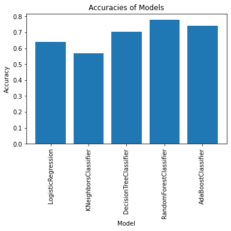

```python
# This code is to plot the results of the accuracy for each model to have a better visualization
# this code was made combining different sources on internet and the lectures
Index = [1,2,3,4,5]
plt.bar(Index,Accuracy)
plt.xticks(Index, Model, rotation=90)
plt.ylabel('Accuracy')
plt.xlabel('Model')
plt.title('Accuracies of Models')
```

### Running Random Forest (with CountVectorizer) to get the Confussion Matrix and Cros val score

```python
forest = RandomForestClassifier(n_estimators=200)

forest = forest.fit(X_train_CV, y_train)

print(forest)
```

```
RandomForestClassifier(bootstrap=True, ccp_alpha=0.0, class_weight=None,
                       criterion='gini', max_depth=None, max_features='auto',
                       max_leaf_nodes=None, max_samples=None,
                       min_impurity_decrease=0.0, min_impurity_split=None,
                       min_samples_leaf=1, min_samples_split=2,
                       min_weight_fraction_leaf=0.0, n_estimators=200,
                       n_jobs=None, oob_score=False, random_state=None,
                       verbose=0, warm_start=False)
```

```python
print(np.mean(cross_val_score(forest, X_test_dense_CV, y_test, cv=10)))
```

```
0.7540960861462
```

```python
# Predict the result for test data using the model built above.

result_forest = forest.predict(X_test_dense_CV)
```

```
[[2575  403  173]
 [ 172  414   99]
 [  67   67  422]]
```

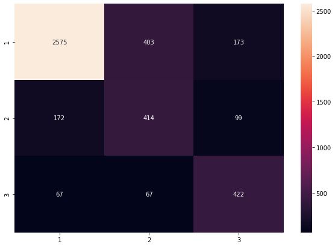

```python
# Print and plot Confusion matirx to get an idea of how the distribution of the prediction is, among all the classes.

import matplotlib.pyplot as plt
import seaborn as sns
from sklearn.metrics import confusion_matrix

conf_mat = confusion_matrix( result_forest, y_test)

print(conf_mat)

df_cm = pd.DataFrame(conf_mat, index = [i for i in "123"],
                  columns = [i for i in "123"])
plt.figure(figsize = (10,7))
sns.heatmap(df_cm, annot=True, fmt='g')

## x= PREDICTED LABEL // Y = TRUE LABEL
```

```python
from sklearn.metrics import accuracy_score,confusion_matrix,classification_report
from mlxtend.plotting import plot_confusion_matrix
```

```python
Accuracy=[]
Model=[]
accuracy = accuracy_score(result_forest,y_test)
Accuracy.append(accuracy)
Model.append(forest.__class__.__name__)
print('Accuracy of '+forest.__class__.__name__+'is '+str(accuracy))
print(classification_report(result_forest,y_test))
```

```
Accuracy of RandomForestClassifieris 0.7766393442622951
              precision    recall  f1-score   support

    negative       0.92      0.82      0.86      3151
     neutral       0.47      0.60      0.53       685
    positive       0.61      0.76      0.68       556

    accuracy                           0.78      4392
   macro avg       0.66      0.73      0.69      4392
weighted avg       0.81      0.78      0.79      4392
```

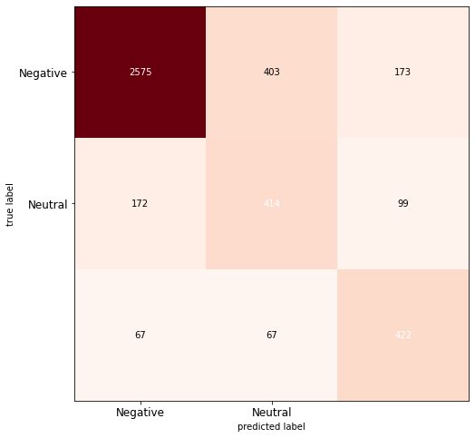

```python
# This is another presentation of the CM
cm=confusion_matrix(result_forest, y_test) # ANOTHER TYPE OF CM
plt.figure()
plot_confusion_matrix(cm,figsize=(12,8), hide_ticks=True,cmap=plt.cm.Reds)
plt.xticks(range(2), ['Negative', 'Neutral', 'Positive'], fontsize=12,color='black')
plt.yticks(range(2), ['Negative', 'Neutral', 'Positive'], fontsize=12)
plt.show()
```

### Decission Tree (with CountVectorizer)

```python
from sklearn.tree import DecisionTreeClassifier
```

```python
tree= DecisionTreeClassifier()
tree= tree.fit (X_train_CV, y_train)
print(tree)

print(np.mean(cross_val_score(tree, X_test_dense_CV, y_test, cv=10)))
```

```
DecisionTreeClassifier(ccp_alpha=0.0, class_weight=None, criterion='gini',
                       max_depth=None, max_features=None, max_leaf_nodes=None,
                       min_impurity_decrease=0.0, min_impurity_split=None,
                       min_samples_leaf=1, min_samples_split=2,
                       min_weight_fraction_leaf=0.0, presort='deprecated',
                       random_state=None, splitter='best')
0.6520894595154276
```

**`The Cross_val_Score of the Decision Tree for count Vectorizer is 65%`**

```python
# Predict the result for test data using the model built above.

result_tree = tree.predict(X_test_dense_CV)
Accuracy=[]
Model=[]

accuracy = accuracy_score(result_tree,y_test)
Accuracy.append(accuracy)
Model.append(tree.__class__.__name__)
print('Accuracy of '+tree.__class__.__name__+'is '+str(accuracy))
print(classification_report(result_tree,y_test))
```

```
Accuracy of DecisionTreeClassifieris 0.7015027322404371
              precision    recall  f1-score   support

    negative       0.80      0.81      0.81      2795
     neutral       0.48      0.45      0.47       950
    positive       0.56      0.60      0.58       647

    accuracy                           0.70      4392
   macro avg       0.62      0.62      0.62      4392
weighted avg       0.70      0.70      0.70      4392
```

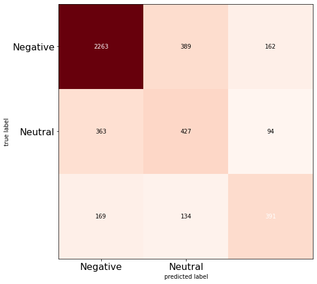

```python
cm=confusion_matrix(y_test, result_tree )
plt.figure()
plot_confusion_matrix(cm,figsize=(12,8), hide_ticks=True,cmap=plt.cm.Reds)
plt.xticks(range(2), ['Negative', 'Neutral', 'Positive'], fontsize=16,color='black')
plt.yticks(range(2), ['Negative', 'Neutral', 'Positive'], fontsize=16)
plt.show()
```

## b.Vectorization: Using TfidfVectorizer.

**In this section I will apply the same steps done in the section a). The only difference will be that the X_train & X_test are coming from TfidfVecotorizer and I will plot the Confusion matrix in the loop so I don't have to repeat the code again**

```python
# Using TfidfVectorizer to convert text data to numbers.

from sklearn.feature_extraction.text import TfidfVectorizer
```

```python
T_vectorizer = TfidfVectorizer(max_features=1000)

X_train_T =T_vectorizer.fit_transform(X_train) # Vectorization (Convert text data X_train to numbers).
X_test_T = T_vectorizer.transform(X_test) # This is to apply the vectorizer already fit to the Test data

X_train_dense_T = X_train_T.toarray()                    # Convert the traing data features to array.
X_test_dense_T = X_test_T.toarray()

print(X_train_dense_T.shape)                                   # Evaluating the shape of the array for train and test
print(X_test_dense_T.shape)
```

```
(10248, 1000)
(4392, 1000)
```

**Using Tfidf we get 1000 columns in contrast with the 9309 columns from CountVectorizer**

### Fit and evaluate model using TfidfVectorizer

*Using a list of model for Prediciting sentiments from tweet text*

```
Accuracy of LogisticRegression is 0.6407103825136612

              precision    recall  f1-score   support

    negative       1.00      0.64      0.78      4392
     neutral       0.00      0.00      0.00         0
    positive       0.00      0.00      0.00         0

    accuracy                           0.64      4392
   macro avg       0.33      0.21      0.26      4392
weighted avg       1.00      0.64      0.78      4392
```

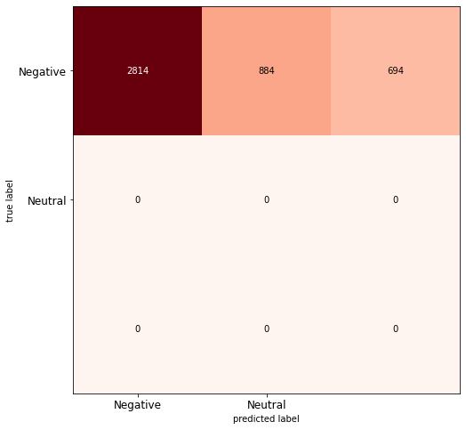

```
Accuracy of KNeighborsClassifier is 0.6732695810564663

              precision    recall  f1-score   support

    negative       0.77      0.80      0.79      2719
     neutral       0.51      0.41      0.45      1116
    positive       0.47      0.59      0.52       557

    accuracy                           0.67      4392
   macro avg       0.59      0.60      0.59      4392
weighted avg       0.67      0.67      0.67      4392
```

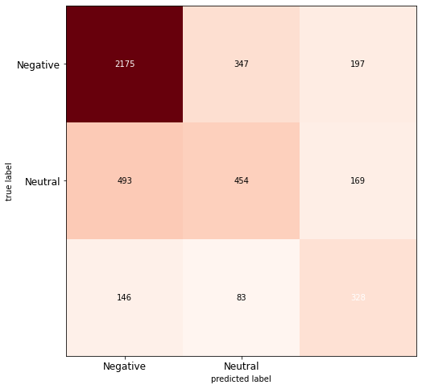

```
Accuracy of DecisionTreeClassifier is 0.6764571948998178

              precision    recall  f1-score   support

    negative       0.77      0.80      0.79      2709
     neutral       0.46      0.41      0.43       976
    positive       0.57      0.56      0.57       707

    accuracy                           0.68      4392
   macro avg       0.60      0.59      0.60      4392
weighted avg       0.67      0.68      0.67      4392
```

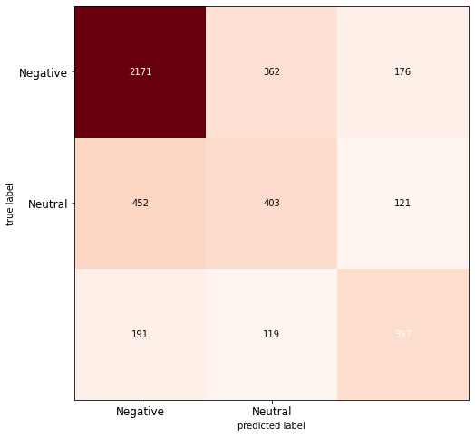

```
Accuracy of RandomForestClassifier is 0.764344262295082

              precision    recall  f1-score   support

    negative       0.92      0.80      0.85      3210
     neutral       0.43      0.59      0.50       644
    positive       0.58      0.75      0.65       538

    accuracy                           0.76      4392
   macro avg       0.64      0.71      0.67      4392
weighted avg       0.80      0.76      0.78      4392
```

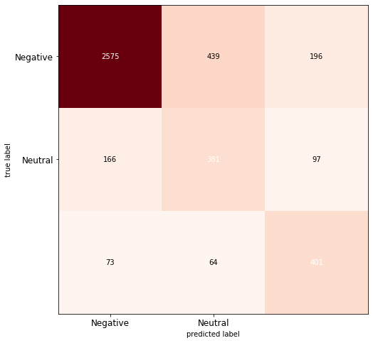

```
Accuracy of AdaBoostClassifier is 0.7390710382513661

              precision    recall  f1-score   support

    negative       0.87      0.80      0.84      3039
     neutral       0.43      0.50      0.46       756
    positive       0.61      0.71      0.65       597

    accuracy                           0.74      4392
   macro avg       0.64      0.67      0.65      4392
weighted avg       0.76      0.74      0.75      4392
```

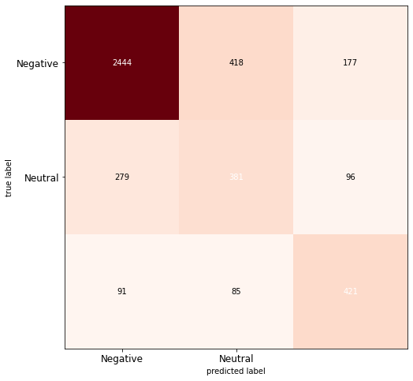

```python
#Classifiers defined already above

#This code below is a combination of different sources on internet and the lectures

Accuracy=[]
Model=[]
for classifier in Classifiers:
    try:
        fit = classifier.fit(X_train_T,y_train)
        pred = fit.predict(X_test_T)
    except Exception:
        fit = classifier.fit(X_train_dense_T,y_train)
        pred = fit.predict(X_test_dense_T)
    accuracy = accuracy_score(pred,y_test)
    Accuracy.append(accuracy)
    Model.append(classifier.__class__.__name__)
    print('Accuracy of '+classifier.__class__.__name__+' is '+str(accuracy))
    print(' ')
    print(classification_report(pred,y_test))
    print(' ')
    cm=confusion_matrix(pred , y_test) # the CM for linear regression will not be considered
    plt.figure()
    plot_confusion_matrix(cm,figsize=(12,8), hide_ticks=True,cmap=plt.cm.Reds)
    plt.xticks(range(2), ['Negative', 'Neutral', 'Positive'], fontsize=12,color='black')
    plt.yticks(range(2), ['Negative', 'Neutral', 'Positive'], fontsize=12)
    plt.show()
```

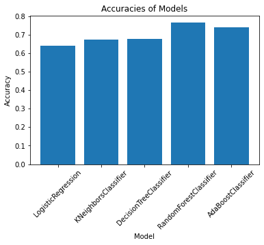

```python
# This code is important to visualize which model has  the best accuracy
Index = [1,2,3,4,5]
plt.bar(Index,Accuracy)
plt.xticks(Index, Model, rotation=45)
plt.ylabel('Accuracy')
plt.xlabel('Model')
plt.title('Accuracies of Models')
```

**`from the 2 results above we can see that Random Forest has the best accuracy with 76%`**

**`The precison and recall of negative feedback is higher than the other for all the models due to it has more number of entries as see in the plots in the APPENDIX`**

# 6. Summarize your understanding of the application of Various Pre-processing and Vectorization and performance of your model on this dataset. (8 Marks)

**About Pre-Processing:**

- The Pre-processing was done using variuos techniques and libraries.
- The pre-processing carried on in this project was done step by step in order to see the result of each command. However, in the real practice it can be much faster making a fuction that compile all the steps and we can run them in 1 go. That will be more efficient.
- Depending on the number of pre-processing steps we can have different results and that should be tested in the real practice. For instance, the impact of the stopword dictionary and negative words. For this excercice I follow the the dictionary of negative words studied in the lectures but i didn't test the model without the personal dictionary to compare the results. -Adjusting the pre-processing we could try to achieve a higher accuracy of the models. -The final goal of the pre-processing is to have a Text data set clean (with useful information) that we can conver to numbers later on.

**Vectorization**

`After some research I found that the split of the data has to be done before the vectorization, I did it in this way and I was able to use the same X_train for both Vectorization techniques.`

- For this project the pre-processed data was transformed to numbers using 2 vectorization techinques.
- The idea of converting the text to number (array) is to be ables to generate a dataset readable by the computer.
- With this vectorized dataset we proceed to feed the models.
- I got better accuracy result of 78% using countvectorizer, however the difference with TfidfVectorizer is only 2%.
- I got 1000 columns in the Tfidf in contrast with more than 9000 columns in countVectorizer, which makes the process with Tfidf much faster and maybe with a bigger dataset it is better to work with Tfidf in term of time and money.

**Modeling**

- In this project I finally managed the way to test different models more efficiently using loops taken from differents sources on the interenet and the lectures.
- Random Forest Classifier gives us the best accuracy score, precision scores according to the classification report and using CountVectorizer. -The confusion matrix shows the TP,TN,FP,FN for all the 3 sentiments(negative,neutral and positive),Here also Random Forest Classifier gives better results than the others. -Also it is possible to see that the negative feedback has the highest precision and recall, and that is because the number of negative feedback is also much higher as observed in one of the graphics in the APPENDIX: negative = 9178 // neutral = 3099 // positive =2363. -The number of negative feedbacks is 3 times or more higher than the others which could affect the results as well due to skewnnes. -in 5 of the 6 airlines we can see that the number of negative feedback is much higher than the other, and only the airline "virgind America" has a normal distribution. -The customer service is the most repeated negative feedback (Customer Service Issue =2910 entries) so this could be the 1st issue to be resolved in order to improve the image of the airlines. -The performance of the model could be improved expending more time in the pre-processing and then adjusting hiperparemeters. -For this excercise the hiperparameter were kept as default.

# 7. CONCLUSIONS

- I was able to create and evalaute different models much faster than in previous project and even make the codes more efficient.
- I found that many display options and EDA can be done with the data before the pre-processing which will allow us to extract extra information from the data set that can be usefull like for instance: analyse the sentiment for each airline, find the most negative and positive words, look the predominant feedback. By doing this we could suggest in the real practice campain to improve the customer feedback for specific areas.
- The appendix below shows some extra display that I would like to keep as a reference for the future. This could be part of the EDA at the beginning fo the project. however due to the lack of time it was done at the end and actually helps to understand the results, for expample the graphics explain why the negative feedback has higher precission.

**Last but not least, I discover that NLP techniques has a lot of application and still there is room for improvement and for us to learn. It can be implemented in any are of work and will make comunication with computers and robots much faster and better in the near future**

# 8. APPENDIX -EXTRA DISPLAYS

**The list of codes below were taking from internet from different sources**

**The most interesting one is the `WorldCloud`**

```python
#counting the number of tweets each airlines has received
data.airline.value_counts()
```

```
United            3822
US Airways        2913
American          2759
Southwest         2420
Delta             2222
Virgin America     504
Name: airline, dtype: int64
```

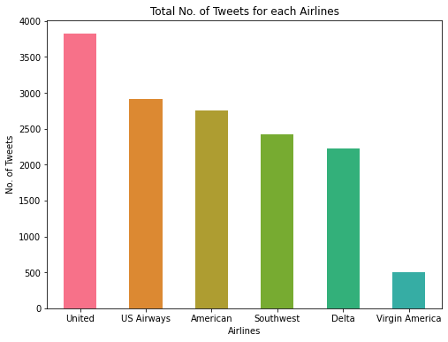

```python
#Plotting the number of tweets each airlines has received
colors=sns.color_palette("husl", 10)
pd.Series(data["airline"]).value_counts().plot(kind = "bar",
                        color=colors,figsize=(8,6),fontsize=10,rot = 0, title = "Total No. of Tweets for each Airlines")
plt.xlabel('Airlines', fontsize=10)
plt.ylabel('No. of Tweets', fontsize=10)
```

```python
#counting the number of each type of sentiments
data.airline_sentiment.value_counts()
```

```
negative    9178
neutral     3099
positive    2363
Name: airline_sentiment, dtype: int64
```

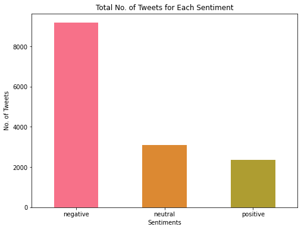

```python
#Plotting the number of each type of sentiments
colors=sns.color_palette("husl", 10)
pd.Series(data["airline_sentiment"]).value_counts().plot(kind = "bar",
                                    color=colors,figsize=(8,6),rot=0, title = "Total No. of Tweets for Each Sentiment")
plt.xlabel('Sentiments', fontsize=10)
plt.ylabel('No. of Tweets', fontsize=10)
```

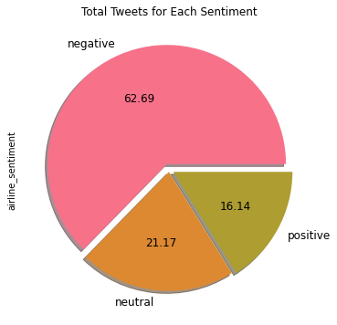

```python
colors=sns.color_palette("husl", 10)
pd.Series(data["airline_sentiment"]).value_counts().plot(kind="pie",colors=colors,
    labels=["negative", "neutral", "positive"],explode=[0.05,0.02,0.04],
    shadow=True,autopct='%.2f', fontsize=12,figsize=(6, 6),title = "Total Tweets for Each Sentiment")
```

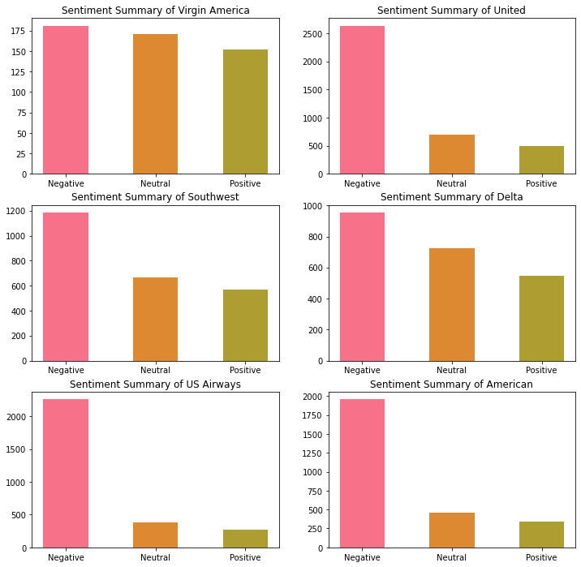

```python
def plot_sub_sentiment(Airline):
    pdf = data[data['airline']==Airline]
    count = pdf['airline_sentiment'].value_counts()
    Index = [1,2,3]
    color=sns.color_palette("husl", 10)
    plt.bar(Index,count,width=0.5,color=color)
    plt.xticks(Index,['Negative','Neutral','Positive'])
    plt.title('Sentiment Summary of' + " " + Airline)

airline_name = data['airline'].unique()
plt.figure(1,figsize=(12,12))
for i in range(6):
    plt.subplot(3,2,i+1)
    plot_sub_sentiment(airline_name[i])
```

```python
#counting the total number of negative reasons
data.negativereason.value_counts()
```

```
Customer Service Issue         2910
Late Flight                    1665
Can't Tell                     1190
Cancelled Flight                847
Lost Luggage                    724
Bad Flight                      580
Flight Booking Problems         529
Flight Attendant Complaints     481
longlines                       178
Damaged Luggage                  74
Name: negativereason, dtype: int64
```

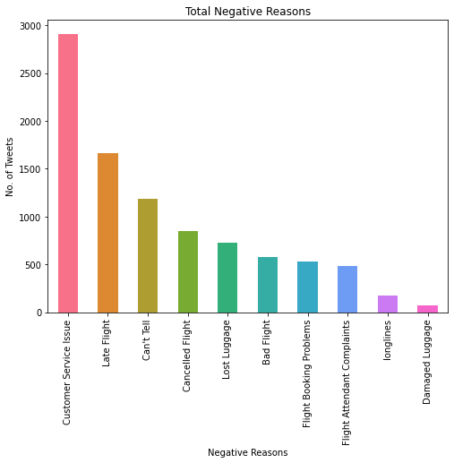

```python
#Plotting all the negative reasons
color=sns.color_palette("husl", 10)
pd.Series(data["negativereason"]).value_counts().plot(kind = "bar",
                        color=color,figsize=(8,6),title = "Total Negative Reasons")
plt.xlabel('Negative Reasons', fontsize=10)
plt.ylabel('No. of Tweets', fontsize=10)
```

```python
data.negativereason.value_counts().head(5)
```

```
Customer Service Issue    2910
Late Flight               1665
Can't Tell                1190
Cancelled Flight           847
Lost Luggage               724
Name: negativereason, dtype: int64
```

```python
#visualization using wordcloud for the negative tweets
df=data[data['airline_sentiment']=='negative']
words = ' '.join(df['text'])
cleaned_word = " ".join([word for word in words.split()
                            if 'http' not in word
                                and not word.startswith('@')
                                and word != 'RT'])
```

```python
from wordcloud import WordCloud,STOPWORDS
```

```python
wordcloud = WordCloud(stopwords=STOPWORDS,
                      background_color='black',
                      width=3000,
                      height=2500
                     ).generate(cleaned_word)
```

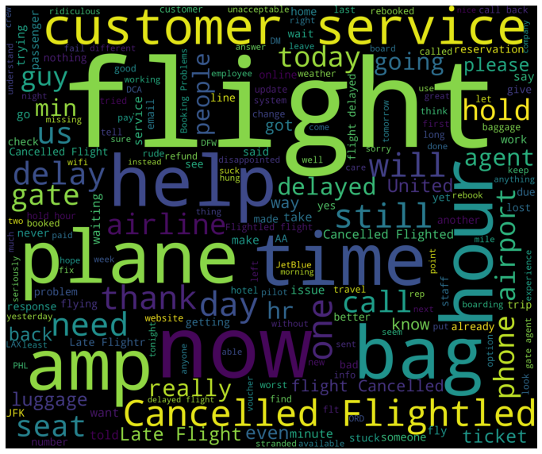

```python
plt.figure(1,figsize=(12, 12))
plt.imshow(wordcloud)
plt.axis('off')
plt.show()
```

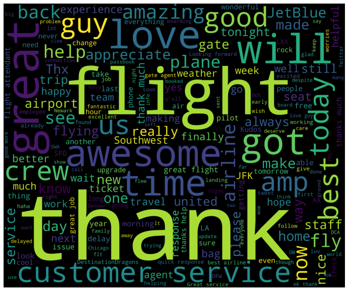

```python
#visualization using wordcloud for the positive tweets
df=data[data['airline_sentiment']=='positive']
words = ' '.join(df['text'])
cleaned_word = " ".join([word for word in words.split()
                            if 'http' not in word
                                and not word.startswith('@')
                                and word != 'RT'])

wordcloud = WordCloud(stopwords=STOPWORDS,
                      background_color='black',
                      width=3000,
                      height=2500
                     ).generate(cleaned_word)

plt.figure(1,figsize=(12, 12))
plt.imshow(wordcloud)
plt.axis('off')
plt.show()
```